# xG From Scratch & the Finishing-Skill Question

Calibrated probabilistic prediction on StatsBomb Open Data

Author

Alejandro Izaguirre

Published

June 15, 2026

## Data & exclusions

StatsBomb Open Data (event + freeze-frame), pulled as raw JSON. Shots are the unit of analysis. **Penalties are excluded** (a different process); direct free kicks are kept but flagged. `shot_statsbomb_xg` is retained purely as a benchmark and is **never** a feature.

| shots | goals | base_rate | players | matches | competitions |
| --- | --- | --- | --- | --- | --- |
| 19887 | 2085 | 0.105 | 2521 | 800 | 6 |

Class balance by competition:

| competition | shots | goals | base_rate |
| --- | --- | --- | --- |
| La Liga | 9356 | 1058 | 0.1130825 |
| FA Women’s Super League | 5869 | 636 | 0.1083660 |
| FIFA World Cup | 2012 | 156 | 0.0775348 |
| UEFA Euro | 1269 | 111 | 0.0874704 |
| Women’s World Cup | 1195 | 105 | 0.0878661 |
| Champions League | 186 | 19 | 0.1021505 |

## EDA

The visual hook — goal rate over pitch location — plus the empirical goal-rate curves against the two dominant geometric features.

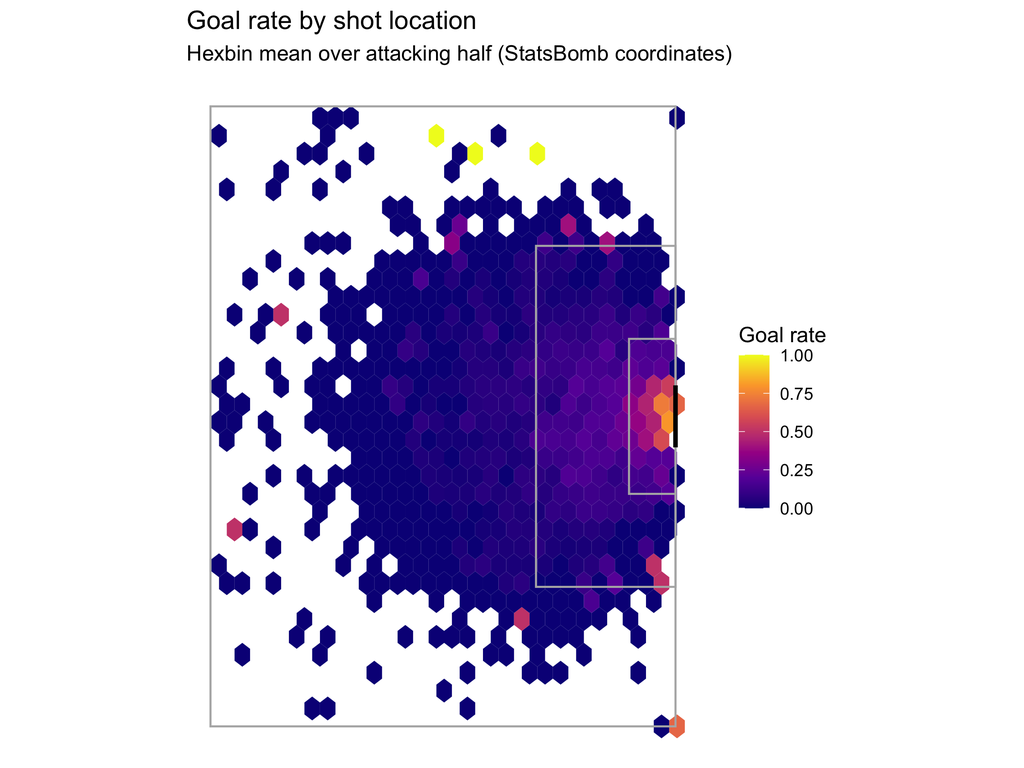

Goal rate by shot location

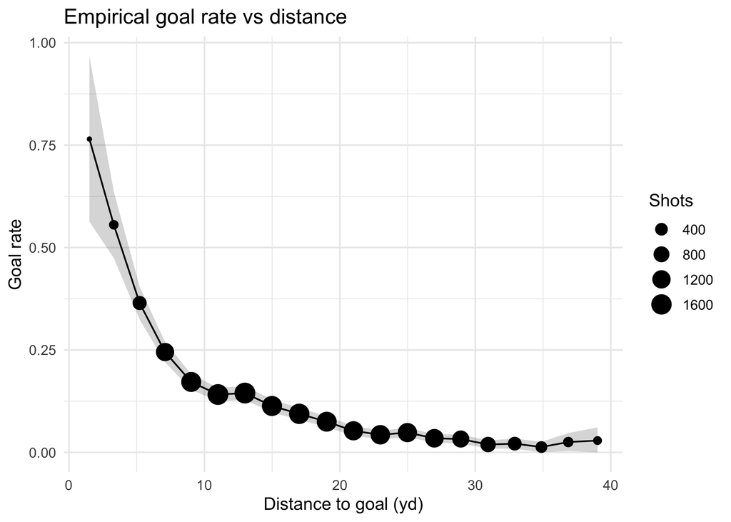

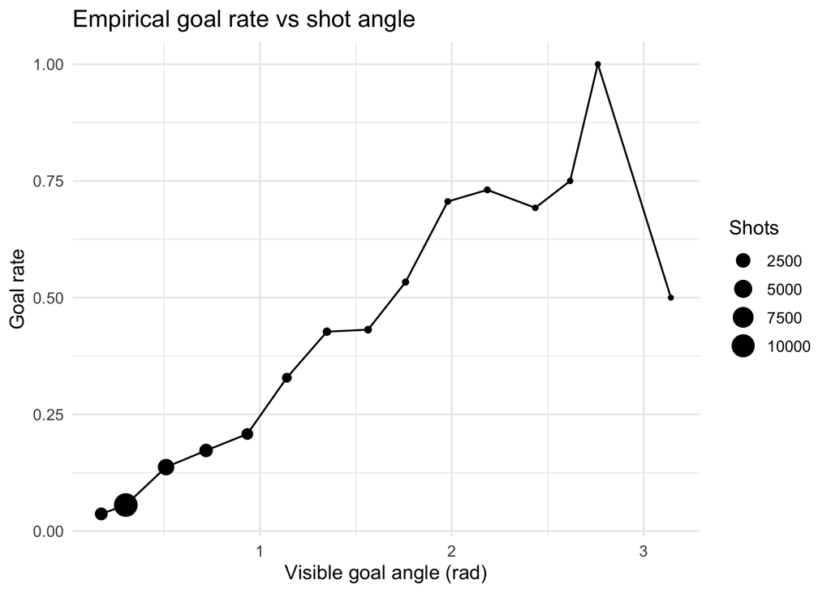

## Models & leakage discipline

Three models on **identical match-grouped CV folds** (shots from one match never span train/test), with out-of-fold predictions for every shot:

- **A — logistic**: `distance + angle + body part` (interpretable baseline).
- **B — GAM**: `mgcv` 2-D spatial smooth `s(x, y)` + context terms.
- **C — xgboost**: full feature set, `nrounds` chosen by inner CV.

| model | log_loss | brier |
| --- | --- | --- |
| statsbomb_xg | 0.2734619 | 0.0776856 |
| xgboost | 0.2758268 | 0.0788739 |
| gam | 0.2832102 | 0.0800803 |
| logistic | 0.2940126 | 0.0840472 |

## Calibration & benchmark vs StatsBomb

Great ranking is not enough — predicted probabilities must be **calibrated**. Reliability diagram (out-of-fold), with ECE and the Murphy/Brier decomposition.

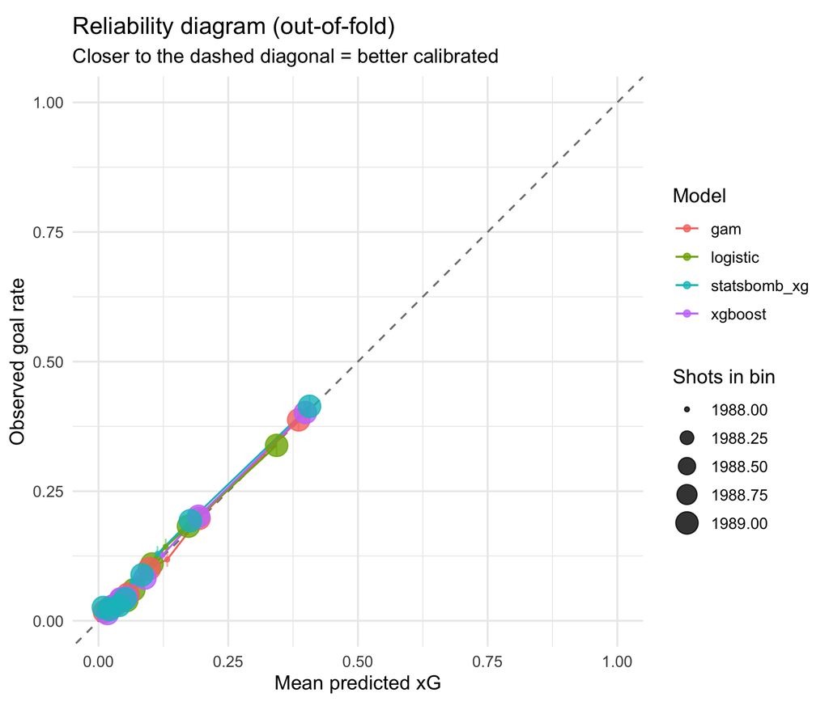

Reliability diagram (out-of-fold)

| model | log_loss | brier | ece | reliability | resolution | uncertainty |
| --- | --- | --- | --- | --- | --- | --- |
| logistic | 0.2940126 | 0.0840472 | 0.0066666 | 0.0001820 | 0.0093023 | 0.0938504 |
| gam | 0.2832102 | 0.0800803 | 0.0029424 | 0.0001599 | 0.0132937 | 0.0938504 |
| xgboost | 0.2758268 | 0.0788739 | 0.0032474 | 0.0000522 | 0.0144093 | 0.0938504 |
| statsbomb_xg | 0.2734619 | 0.0776856 | 0.0064596 | 0.0001155 | 0.0155380 | 0.0938504 |

If the GBM is miscalibrated, leakage-safe isotonic recalibration (fit on other folds, applied out-of-fold):

| metric | xgb_before | xgb_after |
| --- | --- | --- |
| ECE | 0.0032474 | 0.0039271 |
| log_loss | 0.2758268 | 0.2803052 |
| brier | 0.0788739 | 0.0792673 |

**Framing:** the question is “how close can open features get to a production model,” not “I beat StatsBomb.” The gap to `statsbomb_xg` is reported honestly above.

## Finishing skill: real or regression to the mean?

Per-player goals-above-xG, then a hierarchical shrinkage model (`glmer`, player random intercept, model-xG as a logit-scale offset). Low-volume players are pulled toward zero.

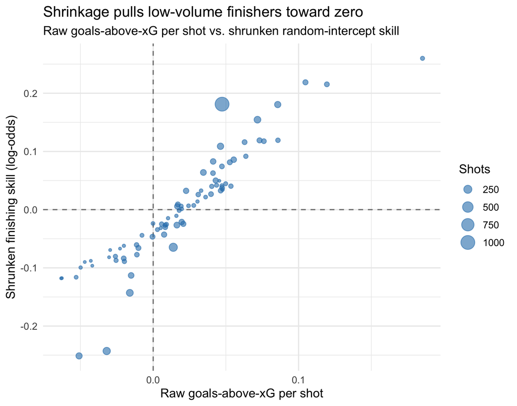

Shrinkage

Top finishers by **shrunken** skill (with 95% intervals):

| player_name | shots | goals | xg | gax | skill_logit | ci |
| --- | --- | --- | --- | --- | --- | --- |
| Alexis Alejandro Sánchez Sánchez | 52 | 17 | 7.4 | 9.6 | 0.260 | [-0.09, 0.61] |
| Lauren James | 81 | 16 | 7.5 | 8.5 | 0.219 | [-0.12, 0.56] |
| Thierry Henry | 72 | 19 | 10.4 | 8.6 | 0.215 | [-0.13, 0.56] |
| Lionel Andrés Messi Cuccittini | 1001 | 168 | 120.6 | 47.4 | 0.181 | [0.02, 0.35] |
| Samuel Eto’’o Fils | 130 | 35 | 23.9 | 11.1 | 0.181 | [-0.12, 0.48] |
| Vivianne Miedema | 156 | 35 | 23.8 | 11.2 | 0.155 | [-0.14, 0.44] |
| Francesc Fàbregas i Soler | 62 | 14 | 8.7 | 5.3 | 0.119 | [-0.23, 0.46] |
| Lauren Hemp | 81 | 16 | 10.1 | 5.9 | 0.119 | [-0.22, 0.45] |
| Khadija Monifa Shaw | 70 | 13 | 7.7 | 5.3 | 0.118 | [-0.23, 0.46] |
| Katie McCabe | 73 | 10 | 5.4 | 4.6 | 0.116 | [-0.24, 0.47] |

Split-half persistence test (odd/even shots; permutation null):

| n_players | split_half_r | perm_p |
| --- | --- | --- |
| 79 | 0.2132479 | 0.055 |

**Verdict:** across 79 players, split-half correlation of finishing over-performance is r = 0.213 (permutation p = 0.055). We cannot reject that finishing over-performance in this sample is mostly noise.

## Limitations

- **Selection bias**: open data skews toward elite competitions; finishing estimates may not transfer to lower levels.
- **No tracking data**: freeze frames are a snapshot at shot moment, not full positioning; defender/GK features are approximations.
- **Sample size**: the finishing-skill verdict is bounded by shots-per-player; the shrinkage and persistence results are about *this* sample.
- `statsbomb_xg` is a black box we benchmark against, not ground truth.

**Note**

StatsBomb data is free for non-commercial use. Attribution: data provided by StatsBomb (https://github.com/statsbomb/open-data).